# Advanced R: Reshaping, merging, and dplyr

Richard Paquin Morel, adapted by Kumar Ramanathans

September 2024

# Let’s get set up

## A new dataset

California energy data

- file names: `ca_energy_generation.csv` and `ca_energy_imports.csv`
- Read these two files into your working environment
  - They are in the “data” folder

## Reading in the data

```r
library(here)
library(readr)
generation <- read.csv(here::here("data/ca_energy_generation.csv"), stringsAsFactors=F)
imports <- read.csv(here::here("data/ca_energy_imports.csv"), stringsAsFactors=F)
```

## Exploring the data

```r
str(generation)
```

```
## 'data.frame':    168 obs. of  12 variables:
##  $ datetime   : chr  "2019-09-03 00:00:00" "2019-09-03 01:00:00" "2019-09-03 02:00:00" "2019-09-03 03:00:00" ...
##  $ biogas     : num  239 239 239 239 238 ...
##  $ biomass    : num  407 406 407 407 406 ...
##  $ coal       : num  9 9 9 9.83 9.42 ...
##  $ geothermal : num  967 970 973 974 975 ...
##  $ large_hydro: num  3152 2724 2630 2611 2651 ...
##  $ natural_gas: num  9711 9155 8078 7801 7744 ...
##  $ nuclear    : num  2249 2251 2251 2245 2243 ...
##  $ other      : int  0 0 0 0 0 0 0 0 0 0 ...
##  $ small_hydro: num  402 401 414 360 382 ...
##  $ solar      : num  0 0 0 0 0 ...
##  $ wind       : num  2670 2779 2795 2583 2397 ...
```

## Dealing with dates and times

- Notice that the first variable in both datasets is called “datetime”
- What class are these variables?

```r
class(generation$datetime)
```

```
## [1] "character"
```

```r
class(imports$datetime)
```

```
## [1] "character"
```

## Dealing with dates/times with `lubridate`

- The best way to deal with date-time data is to use the `lubridate` package
- You can convert character variables into datetime format using the `as_datetime` function
  - One advantage of `readr::read_csv` is that it will often detect and convert datetime variables when importing

```r
library(lubridate)
generation$datetime <- as_datetime(generation$datetime)
class(generation$datetime)
```

```
## [1] "POSIXct" "POSIXt"
```

```r
head(generation$datetime)
```

```
## [1] "2019-09-03 00:00:00 UTC" "2019-09-03 01:00:00 UTC"
## [3] "2019-09-03 02:00:00 UTC" "2019-09-03 03:00:00 UTC"
## [5] "2019-09-03 04:00:00 UTC" "2019-09-03 05:00:00 UTC"
```

## Dealing with dates/times with `lubridate`

```r
imports$datetime <- as_datetime(imports$datetime)
class(imports$datetime)
```

```
## [1] "POSIXct" "POSIXt"
```

```r
head(imports$datetime)
```

```
## [1] "2019-09-03 00:00:00 UTC" "2019-09-03 01:00:00 UTC"
## [3] "2019-09-03 02:00:00 UTC" "2019-09-03 03:00:00 UTC"
## [5] "2019-09-03 04:00:00 UTC" "2019-09-03 05:00:00 UTC"
```

# Reshaping data

## Wide versus long data

- Principles of “tidy data” (*R for Data Science* - Wickham & Grolemund)
  1. Each variable must have its own column.
  2. Each observation must have its own row.
  3. Each value must have its own cell.
- Often, we want to make wide data long (or tidy) for analysis

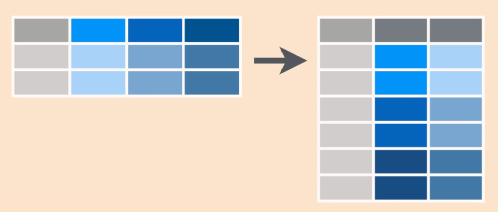

## Wide versus long data

```r
head(generation)
```

```
##              datetime   biogas  biomass      coal geothermal large_hydro
## 1 2019-09-03 00:00:00 238.9167 407.0833  9.000000   967.2500    3152.500
## 2 2019-09-03 01:00:00 239.0000 406.5000  9.000000   970.3333    2724.333
## 3 2019-09-03 02:00:00 239.0000 406.8333  9.000000   973.1667    2630.000
## 4 2019-09-03 03:00:00 238.9167 407.1667  9.833333   973.8333    2611.250
## 5 2019-09-03 04:00:00 237.9167 406.0833  9.416667   974.6667    2651.333
## 6 2019-09-03 05:00:00 237.1667 408.9167 10.000000   973.3333    2965.500
##   natural_gas  nuclear other small_hydro solar     wind
## 1    9710.833 2248.750     0    401.6667     0 2670.167
## 2    9155.000 2250.583     0    400.9167     0 2778.833
## 3    8078.333 2250.833     0    413.5833     0 2795.250
## 4    7801.250 2245.000     0    359.9167     0 2582.583
## 5    7744.333 2242.833     0    382.0833     0 2397.417
## 6    8624.583 2242.833     0    395.9167     0 2327.000
```

## Using `reshape2`

- `melt` –> make data long
- `dcast` –> make data wide
- `recast`–> melt then cast data

## Reshaping CA energy data

- Right now, the `generation` dataframe has several observations per row

```r
head(generation)
```

```
##              datetime   biogas  biomass      coal geothermal large_hydro
## 1 2019-09-03 00:00:00 238.9167 407.0833  9.000000   967.2500    3152.500
## 2 2019-09-03 01:00:00 239.0000 406.5000  9.000000   970.3333    2724.333
## 3 2019-09-03 02:00:00 239.0000 406.8333  9.000000   973.1667    2630.000
## 4 2019-09-03 03:00:00 238.9167 407.1667  9.833333   973.8333    2611.250
## 5 2019-09-03 04:00:00 237.9167 406.0833  9.416667   974.6667    2651.333
## 6 2019-09-03 05:00:00 237.1667 408.9167 10.000000   973.3333    2965.500
##   natural_gas  nuclear other small_hydro solar     wind
## 1    9710.833 2248.750     0    401.6667     0 2670.167
## 2    9155.000 2250.583     0    400.9167     0 2778.833
## 3    8078.333 2250.833     0    413.5833     0 2795.250
## 4    7801.250 2245.000     0    359.9167     0 2582.583
## 5    7744.333 2242.833     0    382.0833     0 2397.417
## 6    8624.583 2242.833     0    395.9167     0 2327.000
```

## `melt` the generation data

`melt(df, id.vars = "id")`

- Specify the variable that *doesn’t* melt with `id.vars`

```r
library(reshape2)
long_gen <- melt(generation, id.vars = "datetime",
                             variable.name = "source",
                             value.name = "usage")
head(long_gen)
```

```
##              datetime source    usage
## 1 2019-09-03 00:00:00 biogas 238.9167
## 2 2019-09-03 01:00:00 biogas 239.0000
## 3 2019-09-03 02:00:00 biogas 239.0000
## 4 2019-09-03 03:00:00 biogas 238.9167
## 5 2019-09-03 04:00:00 biogas 237.9167
## 6 2019-09-03 05:00:00 biogas 237.1667
```

## `melt` the generation data

```r
head(long_gen[order(long_gen$datetime), ])
```

```
##       datetime      source     usage
## 1   2019-09-03      biogas  238.9167
## 169 2019-09-03     biomass  407.0833
## 337 2019-09-03        coal    9.0000
## 505 2019-09-03  geothermal  967.2500
## 673 2019-09-03 large_hydro 3152.5000
## 841 2019-09-03 natural_gas 9710.8333
```

# Merging data

## Merging CA energy data

- Sometimes you have data from two (or more) sources that you want to analyze
- Need to merge these dataframes together
- To merge, need to chose the columns that have common values between the dataframes
  - Usually a variable with ids or years, or both

## Merging the `merge`

`merge(x, y, by = c("id", "year"))`

- Key arguments:
  - `x`: first dataframe
  - `y`: second dataframe
  - `by`: variables to match (must have common name)

## More `merge` arguments

```r
merge(x, y, by.x = "id", by.y = "cd", all.x = T, all.y = T)
```

- Advanced arguments:
  - Use `by.x` and `by.y` if the dataframes have different variable names
  - Use `all.x = T` if you want to keep all the observation in the first dataframe (unmatched observations in `y` are dropped!)
  - Use `all.y = T` if you want to keep all observations in the second dataframe (umatched observations in `x` are dropped!)
  - Use both (or, simply `all = T`) to keep all observations!
  - By **default** R will drop unmatched observations from **both** dataframes!

## Merge by `datetime`

- Use `merge` to join the `generation` and `imports` dataframes, using the `datetime` variable to match

## Merge by `datetime`

- Always check your merge!

```r
merged_energy <- merge(generation, imports, by = "datetime")
dim(merged_energy)
```

```
## [1] 168  13
```

```r
head(merged_energy)
```

```
##              datetime   biogas  biomass      coal geothermal large_hydro
## 1 2019-09-03 00:00:00 238.9167 407.0833  9.000000   967.2500    3152.500
## 2 2019-09-03 01:00:00 239.0000 406.5000  9.000000   970.3333    2724.333
## 3 2019-09-03 02:00:00 239.0000 406.8333  9.000000   973.1667    2630.000
## 4 2019-09-03 03:00:00 238.9167 407.1667  9.833333   973.8333    2611.250
## 5 2019-09-03 04:00:00 237.9167 406.0833  9.416667   974.6667    2651.333
## 6 2019-09-03 05:00:00 237.1667 408.9167 10.000000   973.3333    2965.500
##   natural_gas  nuclear other small_hydro solar     wind  imports
## 1    9710.833 2248.750     0    401.6667     0 2670.167 7527.333
## 2    9155.000 2250.583     0    400.9167     0 2778.833 6930.333
## 3    8078.333 2250.833     0    413.5833     0 2795.250 7005.833
## 4    7801.250 2245.000     0    359.9167     0 2582.583 7080.583
## 5    7744.333 2242.833     0    382.0833     0 2397.417 7421.667
## 6    8624.583 2242.833     0    395.9167     0 2327.000 7511.667
```

## Try reshaping the merged data!

- Our merged dataframe is still wide and untidy
  - Create a long version called `long_merged_energy`
  - Take a peek to make sure the long version looks correct

## Try reshaping the merged data!

```r
long_merged_energy <- melt(merged_energy, id.vars = "datetime",
                           variable.name = "source",
                           value.name = "usage")
head(long_merged_energy)
```

```
##              datetime source    usage
## 1 2019-09-03 00:00:00 biogas 238.9167
## 2 2019-09-03 01:00:00 biogas 239.0000
## 3 2019-09-03 02:00:00 biogas 239.0000
## 4 2019-09-03 03:00:00 biogas 238.9167
## 5 2019-09-03 04:00:00 biogas 237.9167
## 6 2019-09-03 05:00:00 biogas 237.1667
```

# Data manipulation

## Two approaches to data manipulation

- `dplyr`, and `data.table`, are two packages used to process data in tabular form
- it is useful to be familiar with both because:
  - answers to questions on stack overflow will often be presented in a `dplyr` version and a `data.table` version
  - each is built around a different philosophy, so you can choose which suits you most
    - `dplyr`: chain together a few, simple functions
    - `data.table`: compact, syntax-based commands
  - `data.table` is much faster on large data (`dplyr` is explicitly meant for small-to-medium data)

# dplyr!

## dplyr - an idiosyncratic approach to data manipulation

- `dplyr` is an R package for data manipulation developed by Hadley Wickham with help from lots of other R developers
- See https://dplyr.tidyverse.org/ for more guidance
- Principles: consistent syntax, meaningful naming conventions, fewer arguments/more functions

## Load `tidyverse`

```r
library(tidyverse)
```

## `dplyr` verbs

- `select` –> subset variables
- `filter` –> subset observations based on conditions
- `mutate` –> add new variables
- `summarize` –> reduce multiple observations to a single value (e.g., find the mean)

## Trying out `dplyr` verbs - `select`

- select by name:
  - `select(gapminder, continent, pop)`
- select by position:
  - `select(df, c(1, 3, 10))`
- select by range:
  - `select(df, country:pop)` or `select(df, 1:3)`
- drop variables with `-`
  - `select(df, -gdpPercap)`

## Trying out `dplyr` verbs - `select`

```r
tmp <- select(merged_energy, biogas, biomass, geothermal, solar)
names(tmp)
```

```
## [1] "biogas"     "biomass"    "geothermal" "solar"
```

```r
tmp <- select(merged_energy, -biogas, -biomass, -geothermal, -solar)
names(tmp)
```

```
## [1] "datetime"    "coal"        "large_hydro" "natural_gas" "nuclear"
## [6] "other"       "small_hydro" "wind"        "imports"
```

## select helpers

- There are several “select helpers” that make subsetting variables very easy
  - `one_of()`, `contains()`, `starts_with()`, `ends_with()`, `matches()`

```r
tmp <- select(merged_energy, contains("hydro"), starts_with("bio"))
names(tmp)
```

```
## [1] "large_hydro" "small_hydro" "biogas"      "biomass"
```

## `filter`

```r
tmp <- filter(merged_energy, imports > 7000)
nrow(tmp)
```

```
## [1] 78
```

```r
head(tmp)
```

```
##              datetime   biogas  biomass      coal geothermal large_hydro
## 1 2019-09-03 00:00:00 238.9167 407.0833  9.000000   967.2500    3152.500
## 2 2019-09-03 02:00:00 239.0000 406.8333  9.000000   973.1667    2630.000
## 3 2019-09-03 03:00:00 238.9167 407.1667  9.833333   973.8333    2611.250
## 4 2019-09-03 04:00:00 237.9167 406.0833  9.416667   974.6667    2651.333
## 5 2019-09-03 05:00:00 237.1667 408.9167 10.000000   973.3333    2965.500
## 6 2019-09-03 06:00:00 236.7500 406.0833  9.166667   972.3333    3809.500
##   natural_gas  nuclear other small_hydro    solar     wind  imports
## 1    9710.833 2248.750     0    401.6667  0.00000 2670.167 7527.333
## 2    8078.333 2250.833     0    413.5833  0.00000 2795.250 7005.833
## 3    7801.250 2245.000     0    359.9167  0.00000 2582.583 7080.583
## 4    7744.333 2242.833     0    382.0833  0.00000 2397.417 7421.667
## 5    8624.583 2242.833     0    395.9167  0.00000 2327.000 7511.667
## 6    9544.583 2244.833     0    407.5000 77.16667 2048.833 8172.667
```

## multiple conditions in `filter`

```r
tmp <- filter(merged_energy, imports > 7000, natural_gas < 7000)
nrow(tmp)
```

```
## [1] 20
```

```r
head(tmp)
```

```
##              datetime   biogas  biomass     coal geothermal large_hydro
## 1 2019-09-07 03:00:00 240.1667 358.9167 9.166667   964.7500    2413.833
## 2 2019-09-07 06:00:00 238.8333 371.3333 8.500000   971.7500    2649.417
## 3 2019-09-08 00:00:00 236.8333 389.7500 5.416667   970.2500    2697.000
## 4 2019-09-08 01:00:00 237.2500 388.8333 4.750000   969.3333    2654.083
## 5 2019-09-08 02:00:00 237.1667 374.3333 4.083333   969.9167    2217.667
## 6 2019-09-08 03:00:00 237.8333 342.5000 4.000000   972.5000    2090.917
##   natural_gas  nuclear other small_hydro    solar     wind  imports
## 1    6667.417 2255.083     0    378.4167  0.00000 3809.917 7129.667
## 2    6553.917 2257.083     0    408.5000 67.83333 3643.750 7338.250
## 3    6364.333 2251.167     0    403.7500  0.00000 3628.083 8077.583
## 4    5037.917 2254.000     0    403.3333  0.00000 3118.083 8658.583
## 5    4530.750 2255.583     0    385.0833  0.00000 2928.083 8806.583
## 6    4079.500 2257.500     0    377.5000  0.00000 2726.583 8887.167
```

## `mutate`

- `mutate` creates new variables

```r
tmp <- mutate(long_merged_energy, log_usage = log(usage))
head(tmp)
```

```
##              datetime source    usage log_usage
## 1 2019-09-03 00:00:00 biogas 238.9167  5.476115
## 2 2019-09-03 01:00:00 biogas 239.0000  5.476464
## 3 2019-09-03 02:00:00 biogas 239.0000  5.476464
## 4 2019-09-03 03:00:00 biogas 238.9167  5.476115
## 5 2019-09-03 04:00:00 biogas 237.9167  5.471920
## 6 2019-09-03 05:00:00 biogas 237.1667  5.468763
```

## `mutate`

```r
tmp <- mutate(long_merged_energy, log_usage = log(usage), usage2 = usage^2, usage3 = usage^3)
head(tmp)
```

```
##              datetime source    usage log_usage   usage2   usage3
## 1 2019-09-03 00:00:00 biogas 238.9167  5.476115 57081.17 13637644
## 2 2019-09-03 01:00:00 biogas 239.0000  5.476464 57121.00 13651919
## 3 2019-09-03 02:00:00 biogas 239.0000  5.476464 57121.00 13651919
## 4 2019-09-03 03:00:00 biogas 238.9167  5.476115 57081.17 13637644
## 5 2019-09-03 04:00:00 biogas 237.9167  5.471920 56604.34 13467116
## 6 2019-09-03 05:00:00 biogas 237.1667  5.468763 56248.03 13340157
```

## `summarize`

`summarize` reduces observations to a single value based on functions - `mean`, `sum`, `sd`, `min`, `max`, etc.

```r
# total energy consumption
summarize(long_merged_energy, total = sum(usage, na.rm = T))
```

```
##     total
## 1 5223392
```

```r
# mean energy consumption
summarize(long_merged_energy, mean_cons = mean(usage, na.rm = T))
```

```
##   mean_cons
## 1  2590.968
```

## A new operator: the pipe `%>%`

- The powerful `%>%` operator lets you chain together functions
- It sends the result of one function to another function
- Read `%>%` as “then”

```r
# take df then filter it then select these variables
# you do not need to repeat the name of the dataframe!
long_merged_energy %>%
  filter(source == "geothermal") %>%
  select(-datetime) %>%
  mutate(log_usage = log(usage)) %>%
  summarize(mean_log_usage = mean(log_usage, na.rm = T))
```

```
##   mean_log_usage
## 1       6.872053
```

## A new operator: the pipe `%>%`

```r
long_merged_energy %>%
  filter(source == "geothermal")
```

```
##                datetime     source    usage
## 1   2019-09-03 00:00:00 geothermal 967.2500
## 2   2019-09-03 01:00:00 geothermal 970.3333
## 3   2019-09-03 02:00:00 geothermal 973.1667
## 4   2019-09-03 03:00:00 geothermal 973.8333
## 5   2019-09-03 04:00:00 geothermal 974.6667
## 6   2019-09-03 05:00:00 geothermal 973.3333
## 7   2019-09-03 06:00:00 geothermal 972.3333
## 8   2019-09-03 07:00:00 geothermal 972.0833
## 9   2019-09-03 08:00:00 geothermal 968.5000
## 10  2019-09-03 09:00:00 geothermal 963.6667
## 11  2019-09-03 10:00:00 geothermal 959.0833
## 12  2019-09-03 11:00:00 geothermal 954.4167
## 13  2019-09-03 12:00:00 geothermal 944.5833
## 14  2019-09-03 13:00:00 geothermal 944.0833
```

[output cut: 154 more lines]

## A new operator: the pipe `%>%`

```r
long_merged_energy %>%
  filter(source == "geothermal") %>%
  select(-datetime)
```

```
##         source    usage
## 1   geothermal 967.2500
## 2   geothermal 970.3333
## 3   geothermal 973.1667
## 4   geothermal 973.8333
## 5   geothermal 974.6667
## 6   geothermal 973.3333
## 7   geothermal 972.3333
## 8   geothermal 972.0833
## 9   geothermal 968.5000
## 10  geothermal 963.6667
## 11  geothermal 959.0833
## 12  geothermal 954.4167
## 13  geothermal 944.5833
## 14  geothermal 944.0833
```

[output cut: 154 more lines]

## A new operator: the pipe `%>%`

```r
long_merged_energy %>%
  filter(source == "geothermal") %>%
  select(-datetime) %>%
  mutate(log_usage = log(usage))
```

```
##         source    usage log_usage
## 1   geothermal 967.2500  6.874457
## 2   geothermal 970.3333  6.877640
## 3   geothermal 973.1667  6.880555
## 4   geothermal 973.8333  6.881240
## 5   geothermal 974.6667  6.882096
## 6   geothermal 973.3333  6.880727
## 7   geothermal 972.3333  6.879699
## 8   geothermal 972.0833  6.879442
## 9   geothermal 968.5000  6.875748
## 10  geothermal 963.6667  6.870745
## 11  geothermal 959.0833  6.865978
## 12  geothermal 954.4167  6.861100
## 13  geothermal 944.5833  6.850744
## 14  geothermal 944.0833  6.850214
```

[output cut: 154 more lines]

## A new operator: the pipe `%>%`

```r
long_merged_energy %>%
  filter(source == "geothermal") %>%
  select(-datetime) %>%
  mutate(log_usage = log(usage)) %>%
  summarize(mean_log_usage = mean(log_usage, na.rm = T))
```

```
##   mean_log_usage
## 1       6.872053
```

## A new operator: the pipe `%>%`

- While piping, the piped dataframe *is not changed*!
- To refer to the manipulated dataframe, use `.`

```r
merged_energy %>%
  select(-datetime) %>%
  mutate(total_usage = rowSums(., na.rm = T)) %>%
  summarize(total_usage = sum(total_usage, na.rm = T))
```

```
##   total_usage
## 1     5223392
```

## A new operator: the pipe `%>%`

- While piping, the piped dataframe *is not changed*!
- To refer to the manipulated dataframe, use `.`

```r
merged_energy %>%
  select(-datetime) %>%
  mutate(total_usage = rowSums(merged_energy, na.rm = T)) %>%
  summarize(total_usage = sum(total_usage, na.rm = T))
```

```
## Error in `mutate()`:
## ℹ In argument: `total_usage = rowSums(merged_energy, na.rm = T)`.
## Caused by error in `rowSums()`:
## ! 'x' must be numeric
```

## Try piping

- Using the (wide) merged CA energy data `merged_energy` do the following with pipes:
  1. Select variables that contain the word “hydro”
  2. Create a new variable called `total_hydro` that is the sum of the retained hydro variables
  3. Find the mean usage for `total_hydro`

## Try piping

```r
merged_energy %>%
  select(contains("hydro")) %>%
  mutate(total_hydro = rowSums(., na.rm = T)) %>%
  summarize(mean_hydro = mean(total_hydro, na.rm = T))
```

```
##   mean_hydro
## 1   3387.702
```

## `group_by` and `summarize`

- `group_by` is a powerful function that allows us to perform operations by groups of observations!
  - Very useful with summarize!

```r
long_merged_energy %>%
  group_by(source) %>%
  summarize(sum_usage = sum(usage, na.rm = T))
```

```
## # A tibble: 12 × 2
##    source      sum_usage
##    <fct>           <dbl>
##  1 biogas         39427.
##  2 biomass        62890.
##  3 coal            1528.
##  4 geothermal    162114.
##  5 large_hydro   498668.
##  6 natural_gas  1786555.
##  7 nuclear       378618.
##  8 other              0
##  9 small_hydro    70466.
## 10 solar         660315
## 11 wind          440125.
## 12 imports      1122687.
```

## `group_by` versus `for` loops

- Remember the `for` loop we wrote yesterday to find the mean life expectancy by year?
- MUCH better in `dplyr`

## `group_by` versus `for` loops

```r
gapminder <- read.csv(here::here("data/gapminder5.csv"))

gapminder %>%
  group_by(year) %>%
  summarize(mean_le = mean(lifeExp, na.rm = T),
            sd_lf = sd(lifeExp, na.rm = T))
```

```
## # A tibble: 12 × 3
##     year mean_le sd_lf
##    <int>   <dbl> <dbl>
##  1  1952    49.1  12.2
##  2  1957    51.5  12.2
##  3  1962    53.6  12.1
##  4  1967    55.7  11.7
##  5  1972    57.6  11.4
##  6  1977    59.6  11.2
##  7  1982    61.5  10.8
##  8  1987    63.2  10.6
##  9  1992    64.2  11.2
## 10  1997    65.0  11.6
## 11  2002    65.7  12.3
## 12  2007    67.0  12.1
```

## Find the mean by source

- Use your knowledge of `dplyr` to find the mean usage for small hydro, large hydro, biogas, and biomass
- Start with either the wide or long merged dataset

## Find the mean by source

```r
merged_energy %>%
  select(datetime, contains("hydro"), contains("bio")) %>%
  melt(id.vars = "datetime",
       variable.name = "source",
       value.name = "usage") %>%
  group_by(source) %>%
  summarize(mean_usage = mean(usage, na.rm = T))
```

```
## # A tibble: 4 × 2
##   source      mean_usage
##   <fct>            <dbl>
## 1 large_hydro      2968.
## 2 small_hydro       419.
## 3 biogas            235.
## 4 biomass           374.
```

## Merging in `dplyr` with `*_join` functions

- `dplyr`’s philosophy is to have more functions with fewer options
  - `left_join` - keeps all observations in the first dataframe
    - `merge(all.x = T)`
  - `right_join` - keeps all observations in the second dataframe
    - `merge(all.y = T)`
  - `full_join` - keeps all observations in both dataframes
    - `merge(all = T)`
  - `inner_join` - keeps only those observations that are matched in both datasets
    - `merge(all = F)`

## Comparing `merge` and `inner_join`

```r
tmp <- merge(generation, imports, by = "datetime", all = F)
dim(tmp)
```

```
## [1] 168  13
```

```r
tmp <- inner_join(generation, imports, by = "datetime")
dim(tmp)
```

```
## [1] 168  13
```